# Biomedical Image Analysis:

The following example goes over a few of the ways that you can analyze biomedical images. Examples use a 3-dimensional volume of MRI data and sections it down into single images to be analyzed and altered. The aim was to take a closer look at a brain slice and show the many ways that it can be altered to show different aspects of the image.

```python
import imageio as imageio
import matplotlib.pyplot as plt
import scipy.ndimage as ndi
import numpy as np
```

```python
#Importing the volume:
brain = imageio.volread('5.T1_GRE_3D_AXIAL')
```

[output not shown]

Firstly, three separate images are displayed, each from a different plane of view.

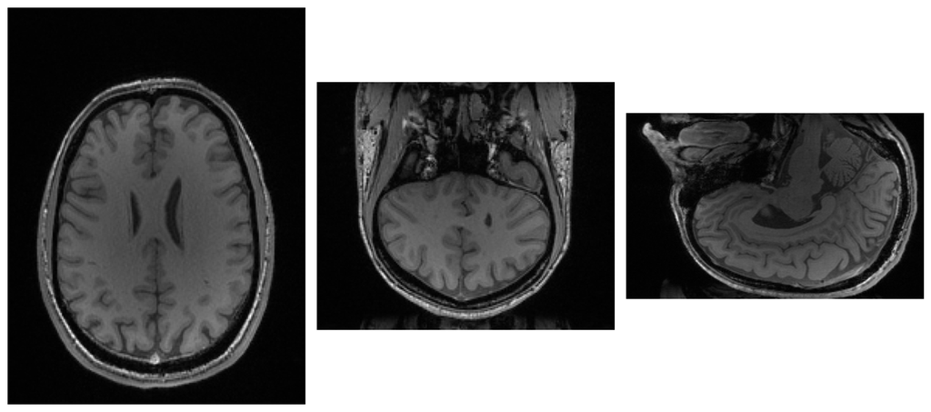

```python
#Plotting slices from the three dimensions:
fig, axes = plt.subplots(nrows=1, ncols=3)
axes[0].imshow(brain[100, :, :], cmap='gray')
axes[1].imshow(brain[:, 100, :], cmap='gray')
axes[2].imshow(brain[:, :, 100], cmap='gray')

for ax in axes:
    ax.axis('off')

plt.tight_layout()
plt.show()
```

The first image is chosen for further analysis. The mass shown in the image is translated to the center of the image. The image is also upsampled to make it appear sharper. The two images are displayed.

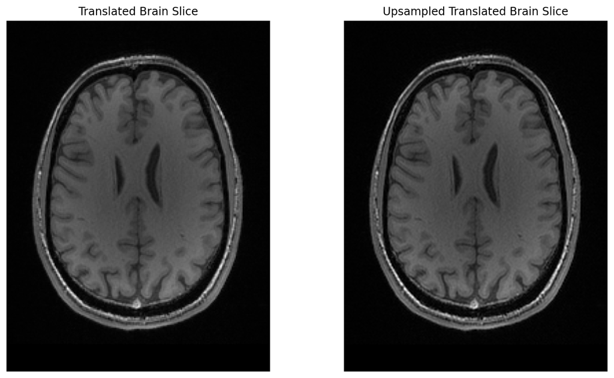

```python
#Translation of the brain image to center mass:
top_v = brain[100, :, :]
com = ndi.center_of_mass(top_v)
d0 = 128 - com[0]
d1 = 96 - com[1]
trans_v = ndi.shift(top_v, shift=[d0, d1])

#Displaying the translated image:
plt.subplot(1, 2, 1)
plt.imshow(trans_v, cmap='gray')
plt.axis('off')
plt.title('Translated Brain Slice')

#Upsampling:
trans_v_up = ndi.zoom(trans_v, zoom=4)

#Displaying upsampled image:
plt.subplot(1, 2, 2)
plt.imshow(trans_v_up, cmap='gray')
plt.axis('off')
plt.title('Upsampled Translated Brain Slice')
plt.show()
```

An intensity histogram is displayed to show the number of pixels that occur within the picture at a certain intensity. We can see that there is a very large amount of pixels at lower intensities, which represents black. This is going to help us determine where to put the threshold for intensity when we make our mask.

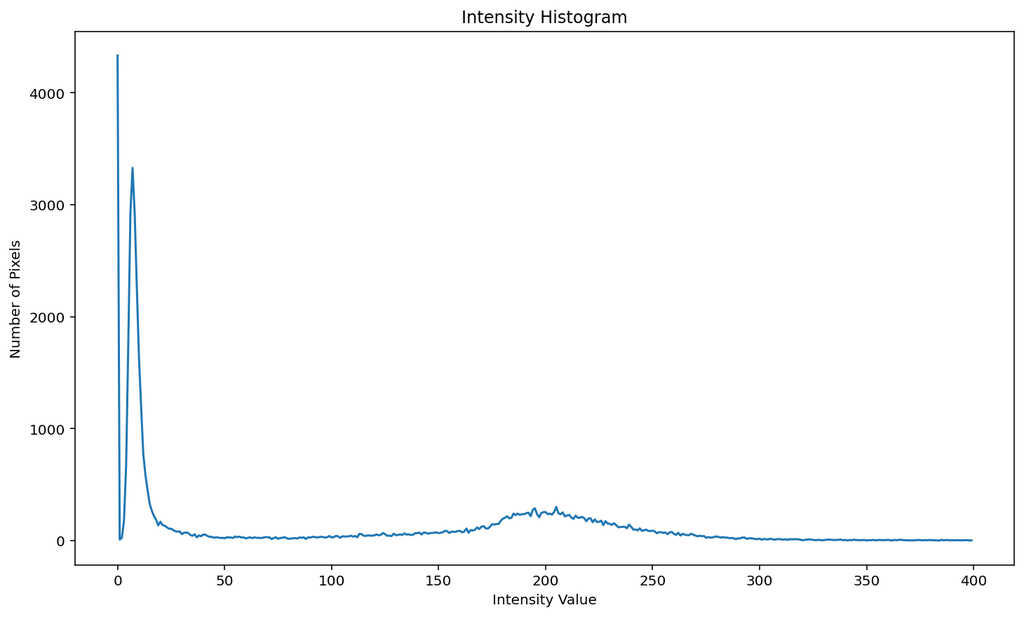

```python
#Intensity histogram:
hist = ndi.histogram(trans_v, min=0, max=400, bins=400)
plt.plot(hist)
plt.ylabel('Number of Pixels')
plt.xlabel('Intensity Value')
plt.title('Intensity Histogram')
plt.show()
```

A few alterations are made to the original image in the following cell. A mask is applied to clear up the edges of the image and to rid the intensity histogram and image of its high number of low intensity (black) values and pixels respectively. Erosion is preformed on the image to clear up blurry edges. A median filter is applied to the image to get a more general view of the slice, removing the grainy details. The original image is displayed as a reference.

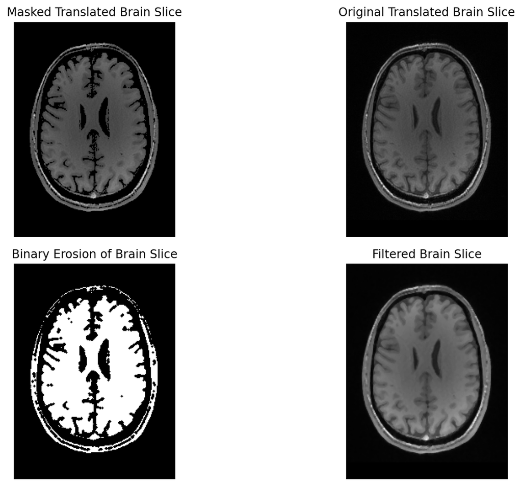

```python
#Masking the brain slice:
trans_v_masked = np.where(trans_v > 150, trans_v, 0)

#Clean up fuzzy edges using binary erosion:
unfuzz_trans = ndi.binary_erosion(trans_v_masked, iterations=1)

#Filter the image:
filtered_trans = ndi.median_filter(trans_v, size = 3)

#Displaying the masked image:
plt.subplot(2, 2, 1)
plt.imshow(trans_v_masked, cmap='gray')
plt.axis('off')
plt.title('Masked Translated Brain Slice')

#Displaying the original image:
plt.subplot(2, 2, 2)
plt.imshow(trans_v, cmap='gray')
plt.axis('off')
plt.title('Original Translated Brain Slice')

#Displaying binary erosion of the slice:
plt.subplot(2, 2, 3)
plt.imshow(unfuzz_trans, cmap='gray')
plt.axis('off')
plt.title('Binary Erosion of Brain Slice')

#Displaying the filtered image:
plt.subplot(2, 2, 4)
plt.imshow(filtered_trans, cmap='gray')
plt.axis('off')
plt.title('Filtered Brain Slice')

plt.tight_layout()
plt.show()
```

Finally, the difference between the 100th and 101st brain slices are displayed. We can see that there does appear to be differences around the edges of the brain structures between brain slices, as to be expected.

[figure not shown]

```python
#Create a second brain slice image to compare to the first:
top_v_2 = brain[101, :, :]

#Create masks of the two images to filter out noise:
top_v_masked = np.where(top_v > 150, top_v, 0)
top_v_2_masked = np.where(top_v_2 > 150, top_v_2, 0)

#Display the difference between the two images:
diff = top_v_masked - top_v_2_masked
plt.imshow(abs_diff, cmap='gray')
plt.colorbar()
plt.axis('off')
plt.title('Difference Between Brain Slices One Slice Apart')

plt.show()
```